# Homework (Chapter 11)

Hwang Seong-Yun

2020 12 2

## 11.31) Refer to the data on salmon in Table 11.2.

```r
salmon <- read.csv("C:/Users/HSY/Desktop/salmon.csv",sep=",",header=T)
salmon$location <- as.factor(salmon$location)
salmon$gender <- as.factor(salmon$gender)
head(salmon)
```

```
##   location gender freshwater marine
## 1        1      2        108    368
## 2        1      1        131    355
## 3        1      1        105    469
## 4        1      2         86    506
## 5        1      1         99    402
## 6        1      2         87    423
```

### (a) Plot the bivariate data for the two groups of salmon. Are the sizes and orientation of the scatters roughly the same? Do bivariate normal distributions with a common covariance matrix appear to be viable population models for the Alaskan and Canadian salmon?

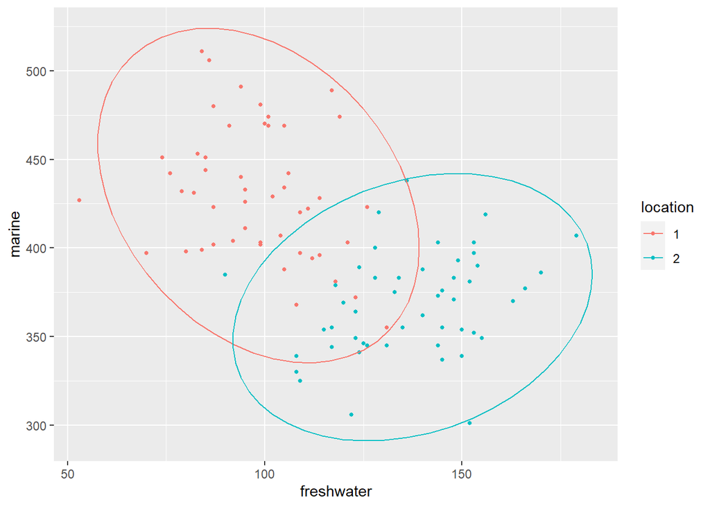

```r
library(ggplot2)
ggplot(salmon) +
  geom_point(aes(x=freshwater, y=marine, color=location),size=1) +
  stat_ellipse(aes(x=freshwater, y=marine, color=location),type = "norm")
```

### (b) Using a linear discriminant function for two normal populations with equal priors and equal costs [see (11-19)], construct dot diagrams of the discriminant scores for the two groups. Does it appear as if the growth ring diameters separate for the two groups reasonably well? Explain.

- ${\hat{y _{0}}} =( {\bar{x _{1}}} - {\bar{x _{2}}} ) ^{T} S _{pooled}^{-1} x _{0}$ , ${\hat{m}} = ( {\bar{x _{1}}} - {\bar{x _{2}}} ) ^{T} S _{pooled}^{-1} ( {\bar{x _{1}}} + {\bar{x _{2}}} )/2$
- Allocate $x _{0}$ to $pi _{ 1}$ if ${\hat{y _{0}}} >= {\hat{m}}$

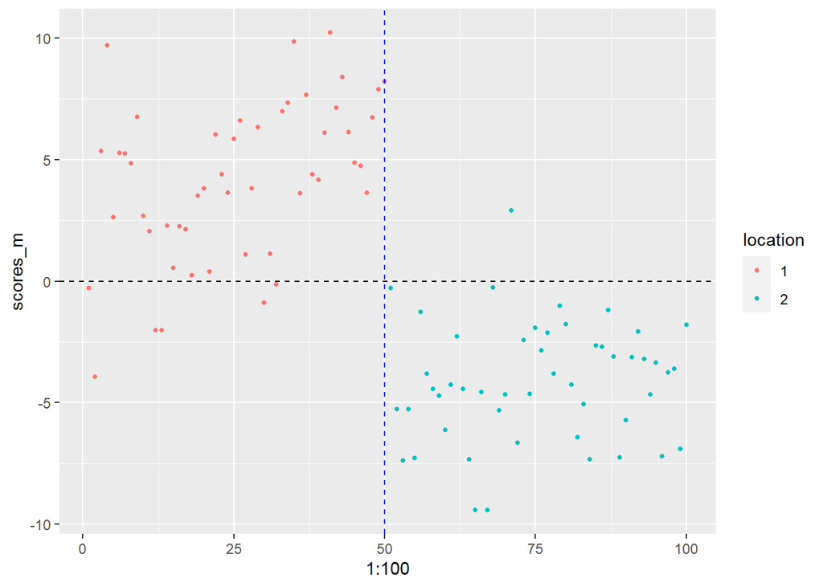

```r
x1 <- colMeans(salmon[salmon$location==1,3:4]) # Alaskan
x2 <- colMeans(salmon[salmon$location==2,3:4]) # Canadian
S1 <- var(salmon[salmon$location==1,3:4])
S2 <- var(salmon[salmon$location==2,3:4])
Sp <- (S1+S2)/2
salmon$scores <- t(t(x1-x2)%*%solve(Sp)%*%t(salmon[,3:4]))
m <- (t(x1-x2)%*%solve(Sp)%*%(x1+x2))/2
salmon$scores_m <- salmon$scores-5.541204
ggplot(salmon) +
  geom_point(aes(x=1:100, y=scores_m, color=location),size=1) +
  geom_hline(yintercept=0, linetype="dashed", color = "black") +
  geom_vline(xintercept=50, linetype="dashed", color = "blue")
```

#### Refer to the dot diagram, I think growth ring diameters separate for the two groups reasonably well.

### (c) Repeat the analysis in Example 11.8 for the male and female salmon separately. Is it easier to discriminate Alaskan male salmon from Canadian male salmon than it is to discriminate the females in the two groups? Is gender (male or female) likely to be a useful discriminatory variable?

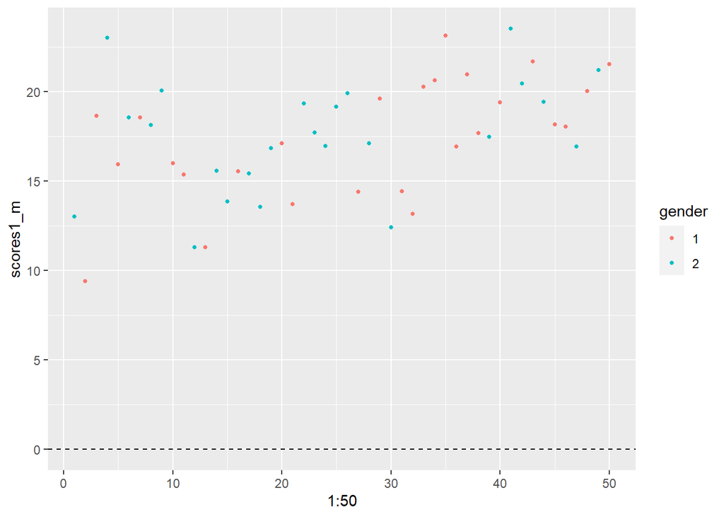

```r
## Alaskan
salmon_Alaskan <- salmon[salmon$location==1,]
x1 <- colMeans(salmon_Alaskan[salmon_Alaskan$gender==1,3:4]) # female
x2 <- colMeans(salmon_Alaskan[salmon_Alaskan$gender==2,3:4]) # male
S1 <- var(salmon_Alaskan[salmon_Alaskan$gender==1,3:4])
S2 <- var(salmon_Alaskan[salmon_Alaskan$gender==2,3:4])
Sp <- (25/48)*S1+(23/48)*S2
salmon_Alaskan$scores1 <- t(t(x1-x2)%*%solve(Sp)%*%t(salmon_Alaskan[,3:4]))
m <- (t(x1-x2)%*%solve(Sp)%*%(x1+x2))/2
salmon_Alaskan$scores1_m <- salmon_Alaskan$scores-(-7.77448)
ggplot(salmon_Alaskan) +
  geom_point(aes(x=1:50, y=scores1_m, color=gender),size=1) +
  geom_hline(yintercept=0, linetype="dashed", color = "black")
```

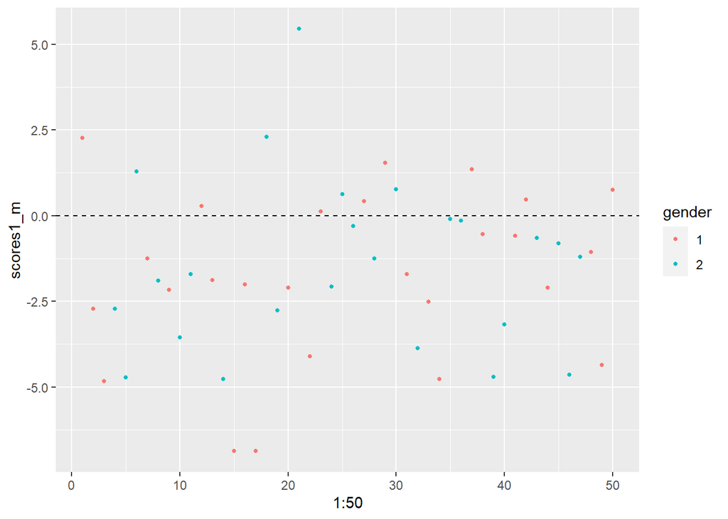

```r
## Canadian
salmon_Canadian <- salmon[salmon$location==2,]
x1 <- colMeans(salmon_Canadian[salmon_Canadian$gender==1,3:4]) # female
x2 <- colMeans(salmon_Canadian[salmon_Canadian$gender==2,3:4]) # male
S1 <- var(salmon_Canadian[salmon_Canadian$gender==1,3:4])
S2 <- var(salmon_Canadian[salmon_Canadian$gender==2,3:4])
Sp <- (25/48)*S1+(23/48)*S2
salmon_Canadian$scores1 <- t(t(x1-x2)%*%solve(Sp)%*%t(salmon_Canadian[,3:4]))
m <- (t(x1-x2)%*%solve(Sp)%*%(x1+x2))/2
salmon_Canadian$scores1_m <- salmon_Canadian$scores-2.994605
ggplot(salmon_Canadian) +
  geom_point(aes(x=1:50, y=scores1_m, color=gender),size=1) +
  geom_hline(yintercept=0, linetype="dashed", color = "black")
```

#### Refer to the result, I think gender is not discriminant variable. Variable location is more useful.

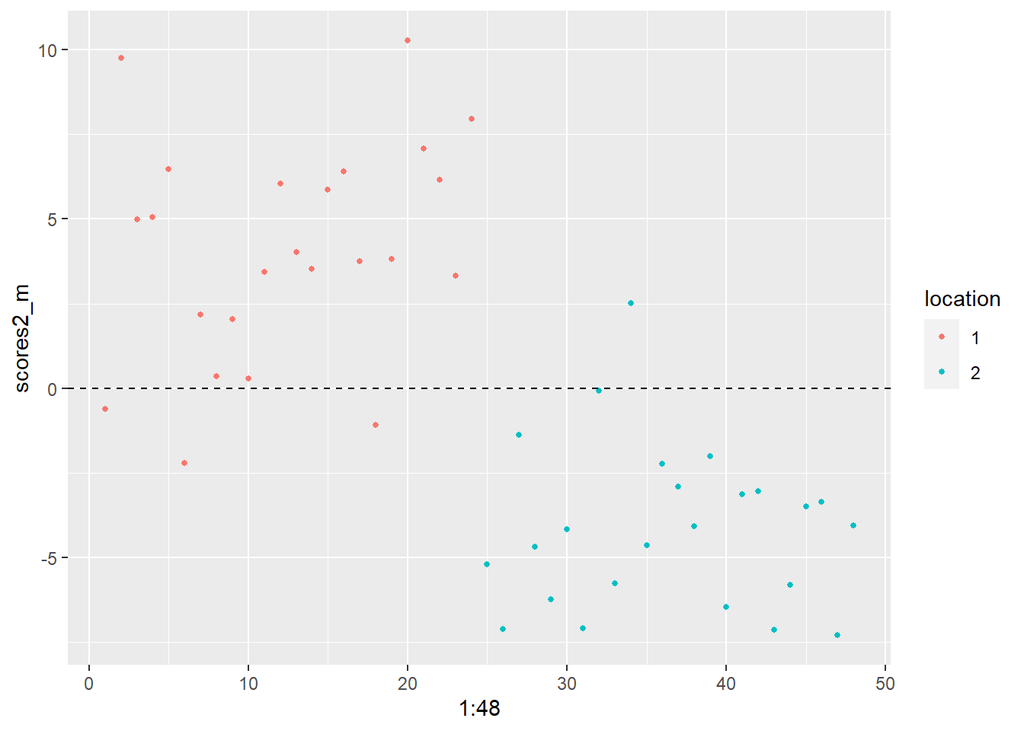

```r
## male
salmon_male <- salmon[salmon$gender==2,]
x1 <- colMeans(salmon_male[salmon_male$location==1,3:4]) # Alaskan
x2 <- colMeans(salmon_male[salmon_male$location==2,3:4]) # Canadian
S1 <- var(salmon_male[salmon_male$location==1,3:4])
S2 <- var(salmon_male[salmon_male$location==2,3:4])
Sp <- (S1+S2)/2
salmon_male$scores2 <- t(t(x1-x2)%*%solve(Sp)%*%t(salmon_male[,3:4]))
m <- (t(x1-x2)%*%solve(Sp)%*%(x1+x2))/2
salmon_male$scores2_m <- salmon_male$scores2-8.124211
ggplot(salmon_male) +
  geom_point(aes(x=1:48, y=scores2_m, color=location),size=1) +
  geom_hline(yintercept=0, linetype="dashed", color = "black")
```

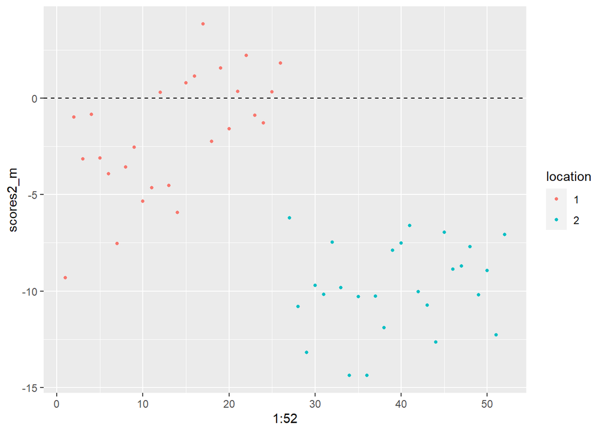

```r
## female
salmon_female <- salmon[salmon$gender==1,]
x1 <- colMeans(salmon_female[salmon_female$location==1,3:4]) # Alaskan
x2 <- colMeans(salmon_female[salmon_female$location==2,3:4]) # Canadian
S1 <- var(salmon_female[salmon_female$location==1,3:4])
S2 <- var(salmon_female[salmon_female$location==2,3:4])
Sp <- (25/46)*S1+(21/46)*S2
salmon_female$scores2 <- t(t(x1-x2)%*%solve(Sp)%*%t(salmon_female[,3:4]))
m <- (t(x1-x2)%*%solve(Sp)%*%(x1+x2))/2
salmon_female$scores2_m <- salmon_female$scores2-8.124211
ggplot(salmon_female) +
  geom_point(aes(x=1:52, y=scores2_m, color=location),size=1) +
  geom_hline(yintercept=0, linetype="dashed", color = "black")
```